# grouphw1

Billy Wang

January 25, 2019

## Intro

Below we see population data gathered from the National Bureau of Statistics of China. Formatting of the original raw file was odd & difficult to work with, so I modified it and cleaned it in a separate file. Below you will see the Gross Domestic Populations of the first 10 provinces, so it matches up well with the Enterprise/Output data, as well as a cut year range from 2000 to 2017.

## Loading Data

This is how to load data into R and how to convert it

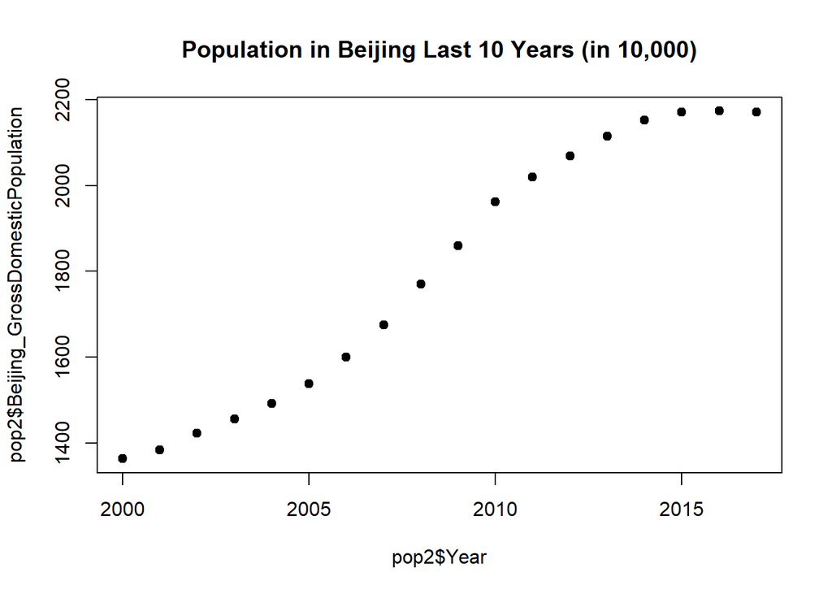

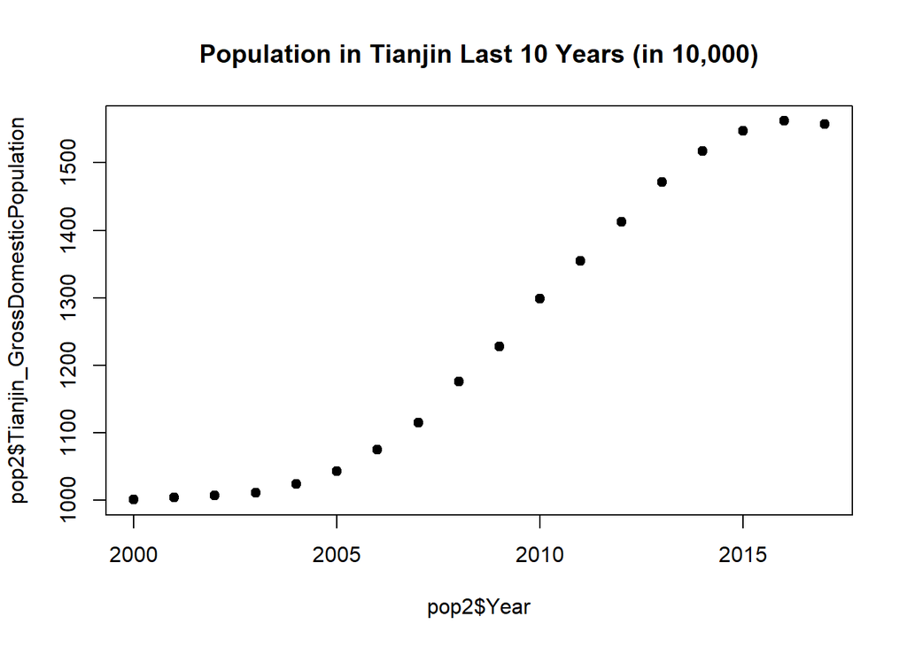

Here we see population graphs for both the province of Beijing as well as Tianjin. Notice how they similarly mark against one another in a logarithmic fashion. As previously mentioned, the timeframe of 2000 to 2017 was chosen purpusely as you can see from around 2000 to ~2010, China was experiencing huge population growth, to the point of exponential codification. However, post 2010 you see a sharp decline in the growth rate as exemplified below, taken as well from the Natural Bureau of of Statistics of China, which causes the progression from exponential growth to a more modest logarithmic. Note that the `echo = FALSE` parameter was added to the code chunk to prevent printing of the R code that generated the plot.

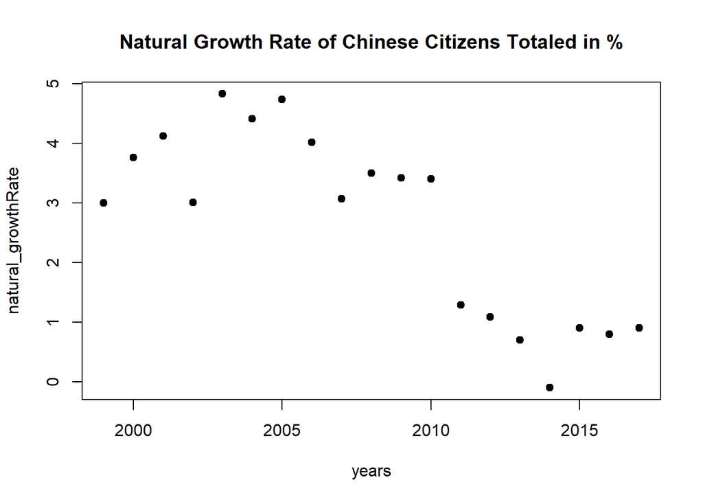

Next, we combine both the Enterprise/Output data, as well as the new Population Data, to check for hidden variables. We will normalize the Enterpise data to the Gross Domestic Population variable to limit the role of external factors and try and derive a relationship from it. Below you will see a function that takes in the province names of all ten listed and calculates it’s enterprise to population ratio, followed by a line plot to add contour to the pattern. It runs through Beijing then Tianjin then Hebei, etc so you the viewer can easily visually compare Enterprise/Population ratios from the top down.

```
##    Year Beijing_Enterprise Beijing_GrossDomesticPopulation    ratio
## 1  2000               4572                            1364 3.351906
## 2  2001               4356                            1385 3.145126
## 3  2002               4551                            1423 3.198173
## 4  2003               4019                            1456 2.760302
## 5  2004               6871                            1493 4.602143
## 6  2005               6300                            1538 4.096229
## 7  2006               6400                            1601 3.997502
## 8  2007               6397                            1676 3.816826
## 9  2008               7205                            1771 4.068323
## 10 2009               6890                            1860 3.704301
## 11 2010               6884                            1962 3.508665
## 12 2011               3746                            2019 1.855374
## 13 2012               3692                            2069 1.784437
## 14 2013               3641                            2115 1.721513
## 15 2014               3686                            2152 1.712825
## 16 2015               3548                            2171 1.634270
## 17 2016               3340                            2173 1.537046
## 18 2017               3231                            2171 1.488254
```

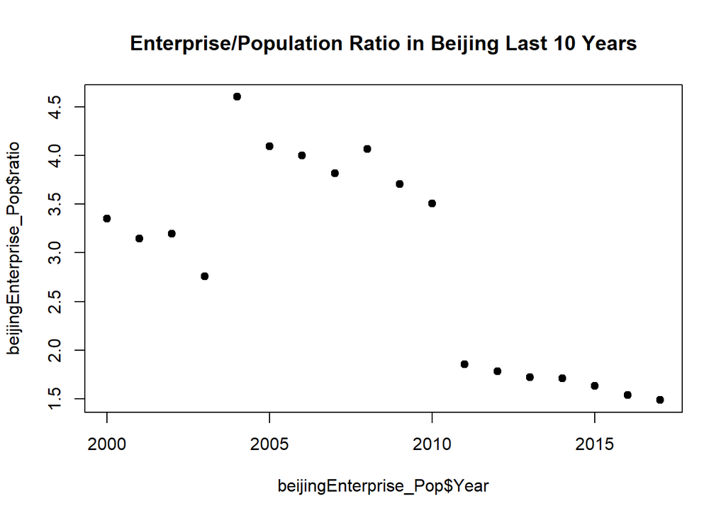

```
##    Beijing_Enterprise
## 1            3.351906
## 2            3.145126
## 3            3.198173
## 4            2.760302
## 5            4.602143
## 6            4.096229
## 7            3.997502
## 8            3.816826
## 9            4.068323
## 10           3.704301
## 11           3.508665
## 12           1.855374
## 13           1.784437
## 14           1.721513
## 15           1.712825
## 16           1.634270
## 17           1.537046
## 18           1.488254
```

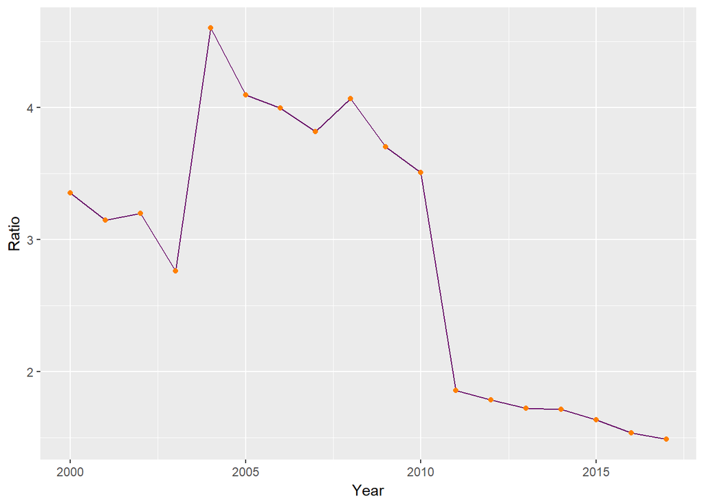

```
##    Tianjin_Enterprise
## 1            5.424575
## 2            5.538845
## 3            5.308838
## 4            5.282888
## 5            6.310547
## 6            5.890700
## 7            5.861395
## 8            5.704933
## 9            6.760204
## 10           6.780130
## 11           6.117783
## 12           3.699631
## 13           3.780609
## 14           3.743886
## 15           3.626236
## 16           3.571429
## 17           3.330986
## 18           2.752730
```

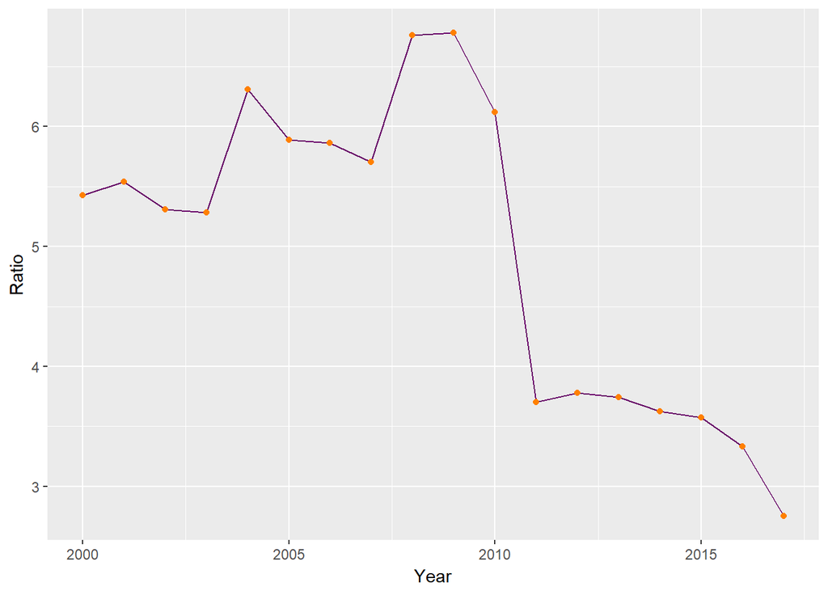

```
##    Hebei_Enterprise
## 1          1.087953
## 2          1.148828
## 3          1.131106
## 4          1.170483
## 5          1.363489
## 6          1.450299
## 7          1.541606
## 8          1.565606
## 9          1.780941
## 10         1.861814
## 11         1.935919
## 12         1.597846
## 13         1.710017
## 14         1.904814
## 15         2.003250
## 16         2.059933
## 17         1.976439
## 18         1.966755
```

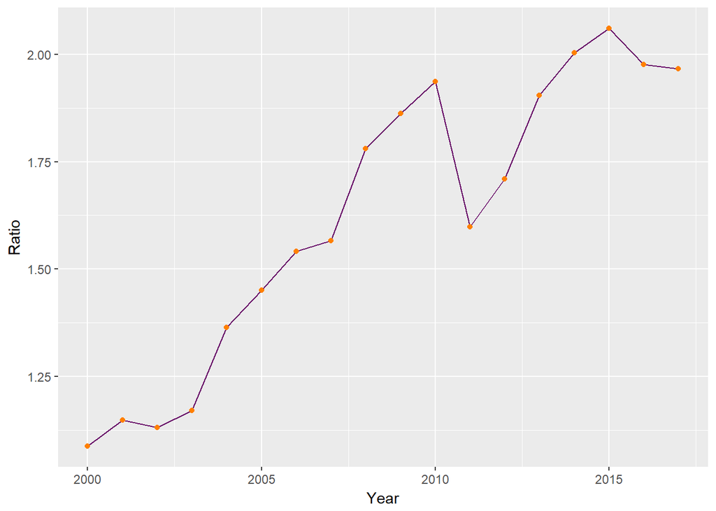

```
##    Shanxi_Enterprise
## 1          1.0086233
## 2          1.0110024
## 3          1.0546448
## 4          1.0902233
## 5          1.5031484
## 6          1.3236960
## 7          1.3831111
## 8          1.3180077
## 9          1.2943418
## 10         1.1739130
## 11         1.1863458
## 12         1.0228222
## 13         1.0814179
## 14         1.0961433
## 15         1.0707237
## 16         1.0493996
## 17         0.9636067
## 18         1.0359265
```

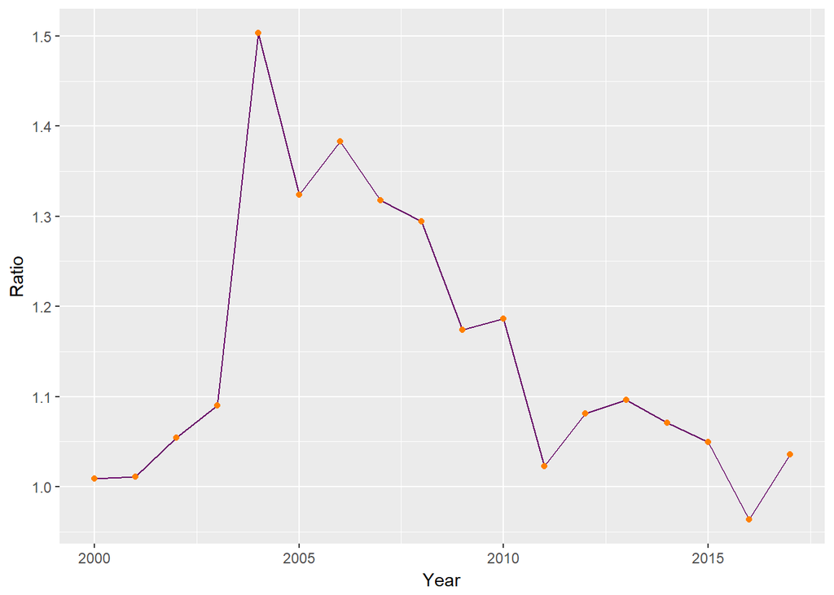

```
##    InnerMongolia_Enterprise
## 1                 0.5788364
## 2                 0.5791684
## 3                 0.6040268
## 4                 0.6927913
## 5                 0.9506895
## 6                 1.0183104
## 7                 1.2732919
## 8                 1.3849321
## 9                 1.6337971
## 10                1.8165175
## 11                1.8652913
## 12                1.6821112
## 13                1.7044177
## 14                1.7630104
## 15                1.7616766
## 16                1.7538829
## 17                1.9737690
## 18                1.1075524
```

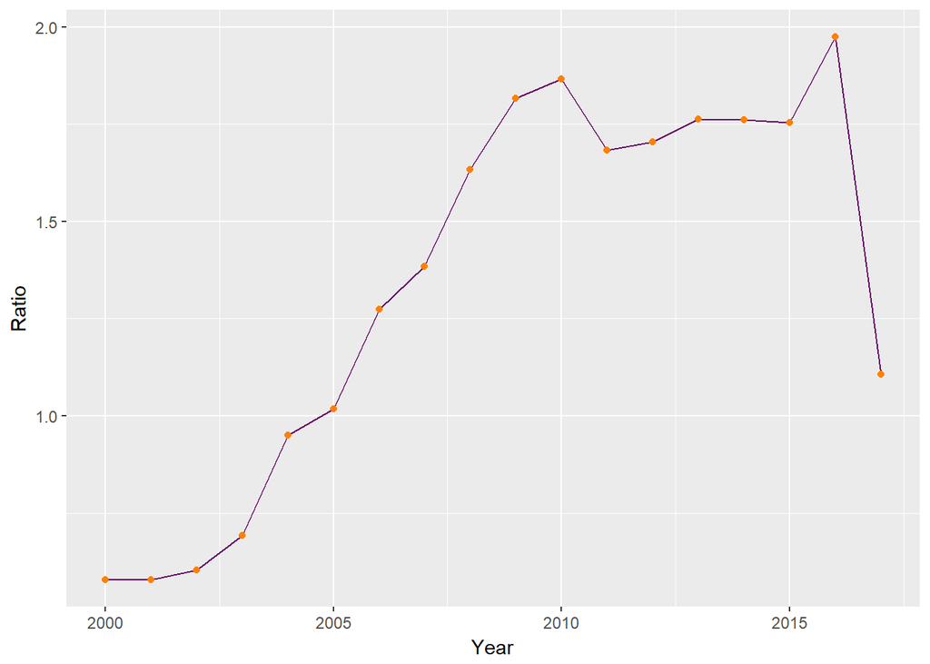

```
##    Liaoning_Enterprise
## 1             1.438098
## 2             1.394134
## 3             1.431596
## 4             1.625178
## 5             2.521935
## 6             2.726842
## 7             3.454460
## 8             3.852024
## 9             5.069757
## 10            5.382170
## 11            5.447314
## 12            3.859001
## 13            3.952381
## 14            3.941913
## 15           35.779043
## 16            2.807850
## 17            5.137644
## 18            1.516594
```

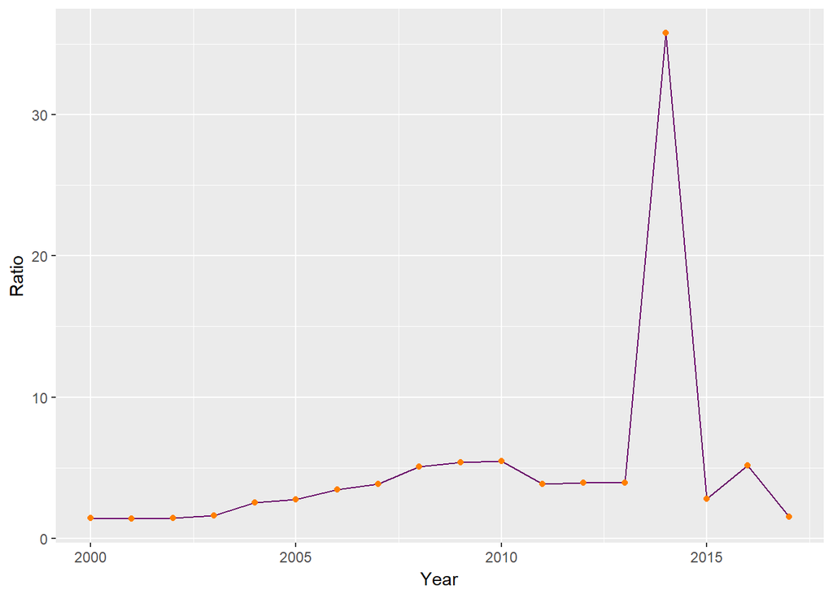

```
##    Jilin_Enterprise
## 1         1.0171514
## 2         0.9691564
## 3         0.9529455
## 4         0.8446746
## 5         1.2107789
## 6         1.0213549
## 7         1.1931693
## 8         1.4593407
## 9         1.9228237
## 10        2.1664234
## 11        2.2665933
## 12        1.8763187
## 13        1.9221818
## 14        1.9541985
## 15        1.9298692
## 16        2.0639303
## 17        0.8036145
## 18        2.1976445
```

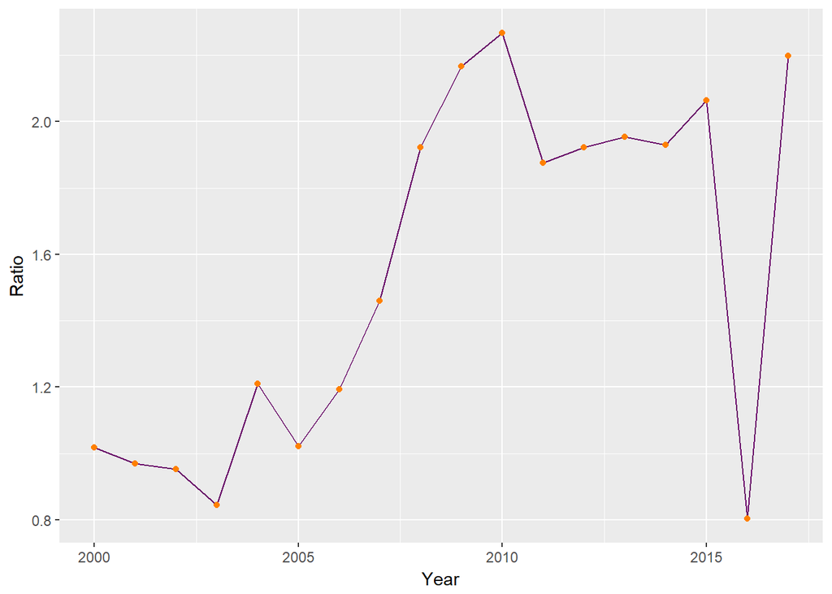

```
##    Heilongjiang_Enterprise
## 1                0.7002889
## 2                0.6559958
## 3                0.6800420
## 4                0.6728702
## 5                0.8637674
## 6                0.7557592
## 7                0.7732148
## 8                0.8294979
## 9                1.1482353
## 10               1.1521171
## 11               1.1990608
## 12               0.8808033
## 13               1.0200835
## 14               1.1468057
## 15               1.1231411
## 16               1.0918153
## 17               1.0717002
## 18               0.9846925
```

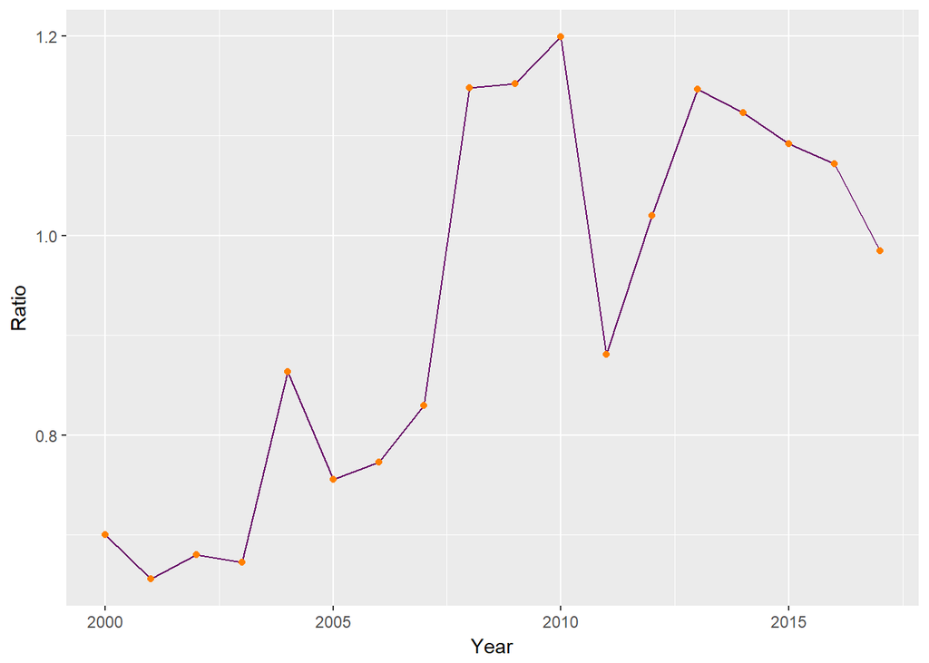

```
##    Shanghai_Enterprise
## 1             5.328776
## 2             5.852518
## 3             5.870987
## 4             6.284258
## 5             8.591826
## 6             7.835450
## 7             7.334012
## 8             7.315407
## 9             8.777207
## 10            8.102262
## 11            7.244464
## 12            4.244568
## 13            4.105882
## 14            4.056315
## 15            3.903133
## 16            3.724224
## 17            3.843074
## 18            3.358974
```

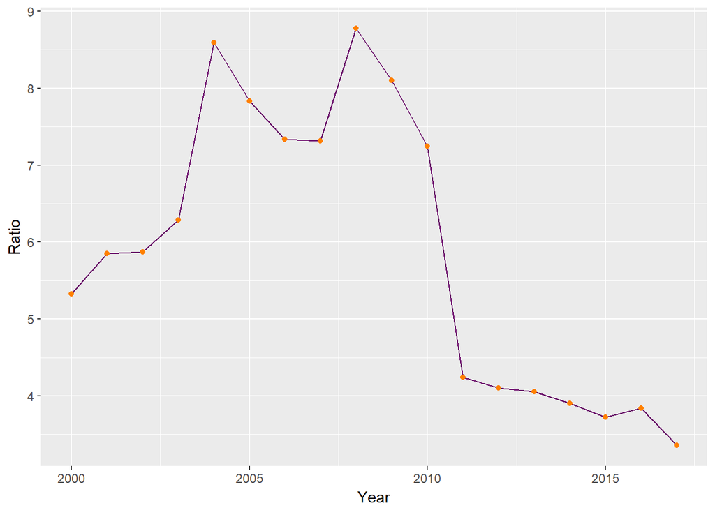